# Reproducible Research: Peer Assessment 1

2025-07-20

## Background

It is now possible to collect a large amount of data about personal movement using activity monitoring devices such as a Fitbit Nike Fuelband or Jawbone Up. These type of devices are part of the “quantified self” movement – a group of enthusiasts who take measurements about themselves regularly to improve their health, to find patterns in their behavior, or because they are tech geeks. But these data remain under-utilized both because the raw data are hard to obtain and there is a lack of statistical methods and software for processing and interpreting the data.

## The variables included in this dataset are:

**date**: The date on which the measurement was taken in YYYY-MM-DD format

**interval**: Identifier for the 5-minute interval in which measurement was taken

The dataset is stored in a comma-separated-value (CSV) file and there are a total of 17,568 observations in this dataset.

Code for reading in the dataset and/or processing the data

```r
activity <- read_csv("activity.csv")
```

Histogram of the total number of steps taken each day

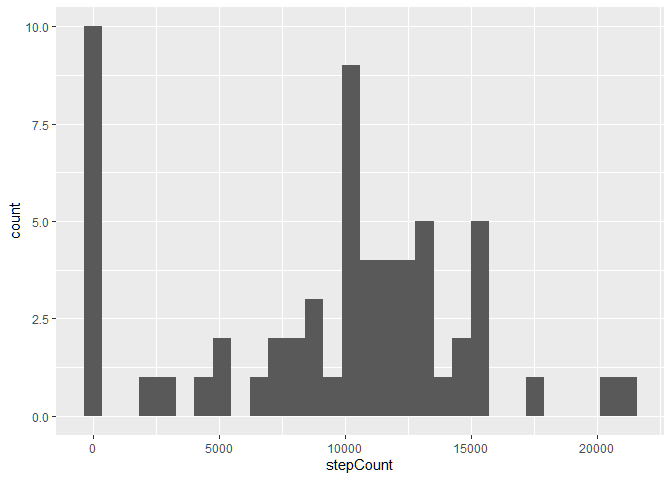

```r
plotData <- activity %>%
            select(steps,date) %>%
            mutate(date = ymd(date)) %>%
            group_by(date) %>%
            summarise(stepCount = sum(steps, na.rm=TRUE))


ggplot(plotData, aes(x = stepCount)) +
    geom_histogram()
```

Mean and median number of steps taken each day

```r
mean(plotData$stepCount)
```

```
## [1] 9354.23
```

```r
median(plotData$stepCount)
```

```
## [1] 10395
```

Time series plot of the average number of steps taken

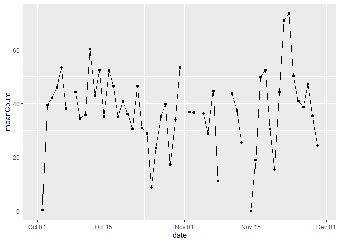

```r
plotData <- activity %>%
    select(steps,date) %>%
    mutate(date = ymd(date)) %>%
    group_by(date) %>%
    summarise(meanCount = mean(steps, na.rm=TRUE))

ggplot(plotData,aes(x= date, y= meanCount))+
    geom_line()+
    geom_point()
```

The 5-minute interval that, on average, contains the maximum number of steps

```r
plotData <- activity %>%
    select(interval,steps) %>%
    group_by(interval) %>%
    summarise(aveSteps = mean(steps, na.rm = TRUE)) %>%
    filter(!is.na(aveSteps)) %>%
    slice_max(aveSteps, n = 1)

table(plotData)
```

```
##         aveSteps
## interval 206.169811320755
##      835                1
```

```r
numZero <- activity$steps
numZeroSum <- sum(numZero == 0, na.rm=TRUE)
```

Code to describe and show a strategy for imputing missing data  
As there are 11014 0 values it was decided to replace all NA with 0

Histogram of the total number of steps taken each day after missing values are imputed

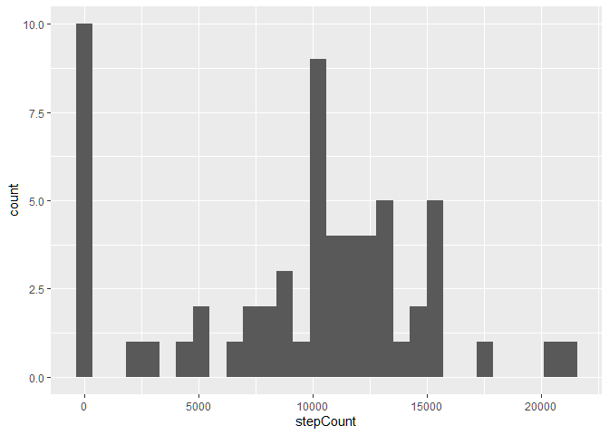

```r
plotData <- activity %>%
    select(steps,date) %>%
    mutate(steps = ifelse(is.na(steps), 0, steps)) %>%
    mutate(date = ymd(date)) %>%
    group_by(date) %>%
    summarise(stepCount = sum(steps, na.rm=TRUE))


ggplot(plotData, aes(x = stepCount)) +
    geom_histogram()
```

Panel plot comparing the average number of steps taken per 5-minute interval across weekdays and weekends

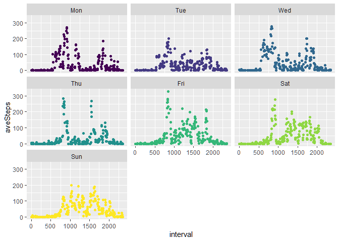

```r
plotData <- activity %>%
    select(interval,steps,date) %>%
    mutate(date = ymd(date)) %>%
    mutate(date = wday(date, label=TRUE,week_start = 1)) %>%
    group_by(interval,date) %>%
    summarise(aveSteps = mean(steps, na.rm = TRUE))
ggplot(plotData, aes(x = interval, y = aveSteps, color = date)) +
    geom_point(show.legend = FALSE) +
    facet_wrap(~date)
```